# Prevalences and risk for being diagnosed

## Cardiovascular conditions

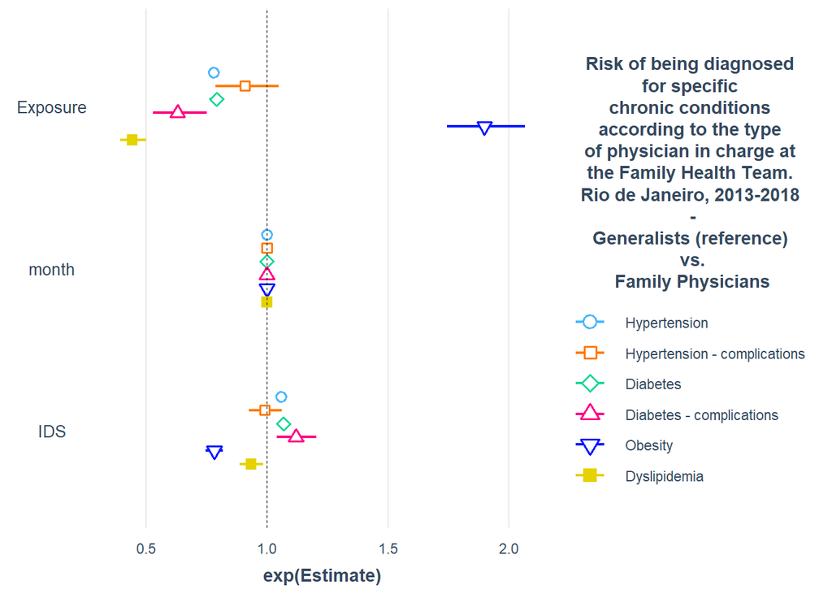

Risk of being diagnosed with a condition regarding to the type of doctor in charge adjusted by the social development index and time. Rio de Janeiro, 2013 to 2018

Hypertension

Hypertension - complications

Diabetes

Diabetes - complications

Obesity

Dyslipidemia

Predictors

IRR

IRR

IRR

IRR

IRR

IRR

Family Physician

0.78 ***  
(0.76 – 0.80)

0.91  
(0.79 – 1.05)

0.79 ***  
(0.76 – 0.82)

0.63 ***  
(0.53 – 0.75)

1.90 ***  
(1.74 – 2.07)

0.44 ***  
(0.39 – 0.50)

Month

1.00 ***  
(1.00 – 1.00)

1.00  
(1.00 – 1.00)

1.00 ***  
(1.00 – 1.00)

1.00 ***  
(1.00 – 1.00)

1.00 ***  
(1.00 – 1.00)

1.00 **  
(1.00 – 1.00)

Social Development Index

4.70 ***  
(3.56 – 6.20)

0.77  
(0.12 – 4.78)

5.95 ***  
(3.67 – 9.61)

20.95 **  
(2.84 – 148.00)

0.00 ***  
(0.00 – 0.00)

0.16 *  
(0.04 – 0.66)

Observations

3219

3219

3219

3219

3219

3219

- p<0.05 ** p<0.01 *** p<0.001

## Mental health conditions

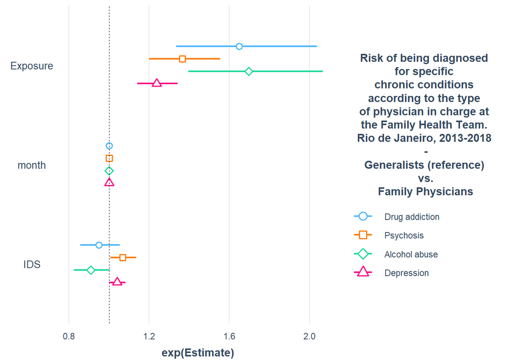

Risk of being diagnosed with a condition regarding to the type of doctor in charge adjusted by the social development index and time. Rio de Janeiro, 2013 to 2018

Drug addiction

Psychosis

Alcohol abuse

Depression

Predictors

IRR

IRR

IRR

IRR

Family Physician

1.65 ***  
(1.33 – 2.04)

1.36 ***  
(1.20 – 1.55)

1.70 ***  
(1.39 – 2.07)

1.24 ***  
(1.14 – 1.34)

Month

1.00 ***  
(1.00 – 1.00)

1.00 ***  
(1.00 – 1.00)

1.00 ***  
(1.00 – 1.00)

1.00 ***  
(1.00 – 1.00)

Social Development Index

0.25  
(0.01 – 3.85)

5.86 *  
(1.13 – 29.54)

0.08  
(0.01 – 1.03)

2.90 *  
(1.02 – 8.14)

Observations

3219

3219

3219

3219

- p<0.05 ** p<0.01 *** p<0.001

## Hypothyroidism, Arrythmias, Coagulopathy, Rheumathism, Valvulopathy and Neurological conditions

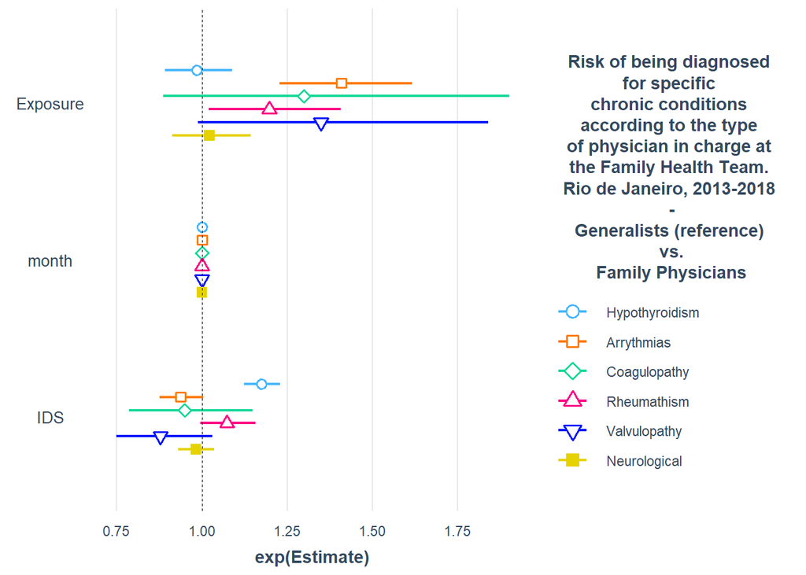

Risk of being diagnosed with a condition regarding to the type of doctor in charge adjusted by the social development index and time. Rio de Janeiro, 2013 to 2018

Hypothyroidism

Arrythmias

Coagulopathy

Rheumathism

Valvulopathy

Neurological

Predictors

IRR

IRR

IRR

IRR

IRR

IRR

Family Physician

0.99  
(0.89 – 1.09)

1.41 ***  
(1.23 – 1.62)

1.30  
(0.89 – 1.90)

1.20 *  
(1.02 – 1.41)

1.35  
(0.99 – 1.84)

1.02  
(0.91 – 1.14)

Month

1.00  
(1.00 – 1.00)

1.00 ***  
(1.00 – 1.00)

1.00 ***  
(1.00 – 1.00)

1.00 *  
(1.00 – 1.00)

1.00 *  
(1.00 – 1.00)

1.00  
(1.00 – 1.00)

Social Development Index

76.42 ***  
(22.74 – 253.18)

0.18  
(0.03 – 1.10)

0.25  
(0.00 – 35.70)

6.73  
(0.87 – 49.91)

0.03  
(0.00 – 2.01)

0.62  
(0.14 – 2.61)

Observations

3219

3219

3219

3219

3219

3219

- p<0.05 ** p<0.01 *** p<0.001

## Stroke, Dementia, Ischemic heart disease, Heart failure, COPD, Kidney failure,

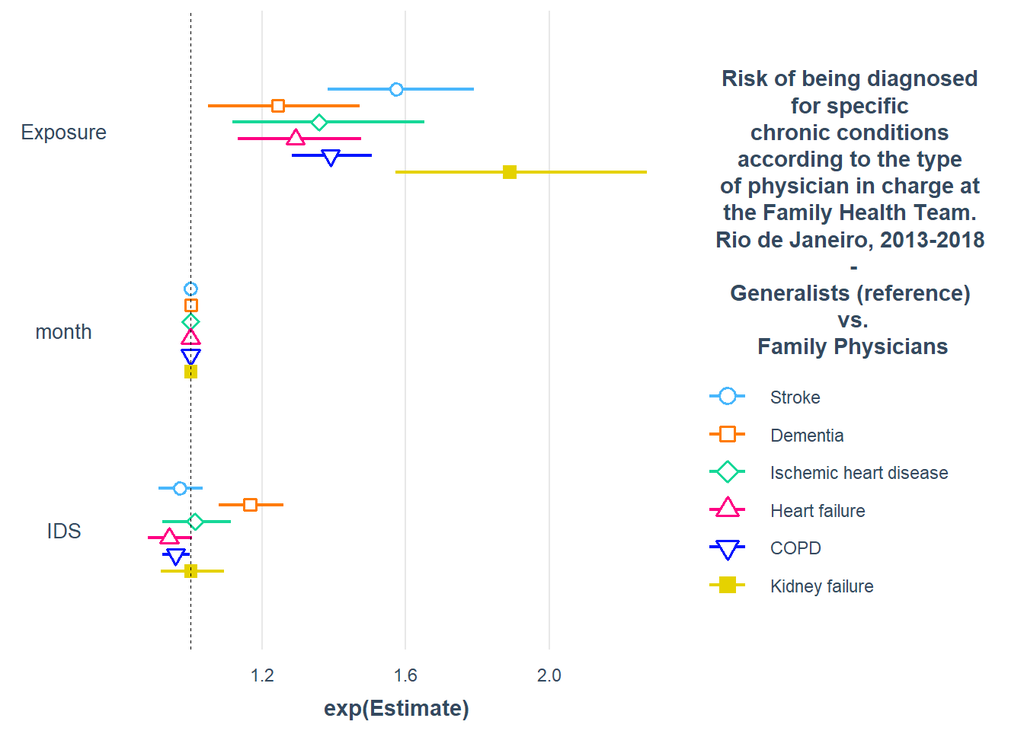

Risk of being diagnosed with a condition regarding to the type of doctor in charge adjusted by the social development index and time. Rio de Janeiro, 2013 to 2018

Stroke

Dementia

Ischemic heart disease

Heart failure

COPD

Kidney failure

Predictors

IRR

IRR

IRR

IRR

IRR

IRR

Family Physician

1.57 ***  
(1.38 – 1.79)

1.24 *  
(1.05 – 1.47)

1.36 **  
(1.12 – 1.65)

1.29 ***  
(1.13 – 1.47)

1.39 ***  
(1.28 – 1.51)

1.89 ***  
(1.57 – 2.27)

Month

1.00 ***  
(1.00 – 1.00)

1.00 ***  
(1.00 – 1.00)

1.00 ***  
(1.00 – 1.00)

1.00 ***  
(1.00 – 1.00)

1.00 ***  
(1.00 – 1.00)

1.00 ***  
(1.00 – 1.00)

Social Development Index

0.44  
(0.08 – 2.36)

60.89 ***  
(7.47 – 477.57)

1.39  
(0.11 – 17.01)

0.19  
(0.03 – 1.11)

0.32 *  
(0.11 – 0.92)

1.04  
(0.10 – 10.47)

Observations

3219

3219

3219

3219

3219

3219

- p<0.05 ** p<0.01 *** p<0.001

## Intrauterine device, Inflamatory pelvic disease, Pyodermitis and AIDS

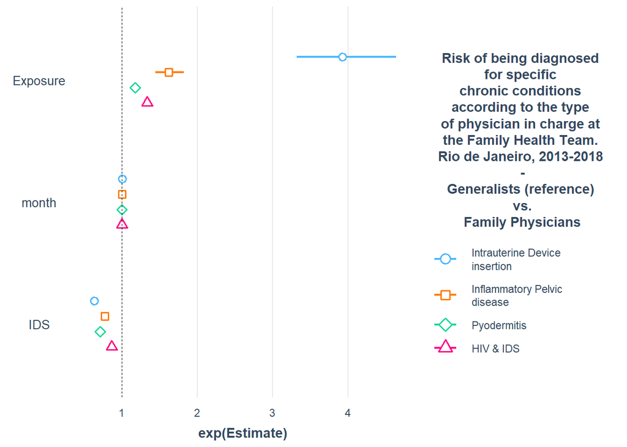

Risk of being diagnosed with a condition regarding to the type of doctor in charge adjusted by the social development index and time. Rio de Janeiro, 2013 to 2018

Intrauterine Device insertion

Inflammatory Pelvic disease

Pyodermitis

HIV & AIDS

Predictors

IRR

IRR

IRR

IRR

Family Physician

3.93 ***  
(3.33 – 4.65)

1.62 ***  
(1.44 – 1.82)

1.18 ***  
(1.13 – 1.23)

1.33 ***  
(1.29 – 1.38)

Month

1.00 ***  
(1.00 – 1.00)

1.00 ***  
(1.00 – 1.00)

1.00 ***  
(1.00 – 1.00)

1.00 ***  
(1.00 – 1.00)

Social Development Index

0.00 ***  
(0.00 – 0.00)

0.00 ***  
(0.00 – 0.01)

0.00 ***  
(0.00 – 0.00)

0.02 ***  
(0.01 – 0.03)

Observations

3219

3219

3219

3219

- p<0.05 ** p<0.01 *** p<0.001